# R Notebook

# Loading in libraries

```r
library(tidyverse)
library(janitor)
library(ggiraphExtra)
library(GGally)
library(fastDummies)
```

# 1. Reading in data and exploring

```r
diamonds <- read_csv("diamonds.csv")

glimpse(diamonds)
```

# 2. Using ggpairs() to identify if there are strong correlations between x, y, z variables and carat variable

```r
ggpairs(diamonds)
```

It appears there is a strong correlation between the letter variables and carat

# 3. Dropping x, y, z variables (as carat can be used to describe size)

```r
diamonds_clean <- diamonds %>%
  select(-c("x", "y", "z"))
```

# 4. (i) Using ggpairs() to determine whether there is a storng correlation between price and predictor variables and then (ii) plotting any significant correlations found

```r
ggpairs(diamonds_clean)
```

Very strong correlation between price and carat (0.922)

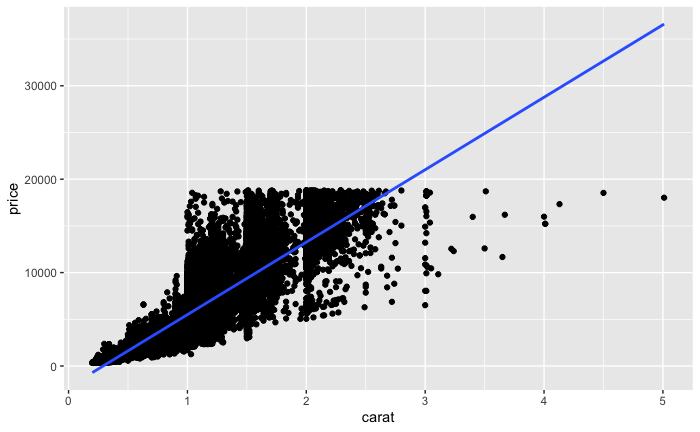

```r
diamonds_clean %>%
  ggplot() +
  aes(x = carat, y = price) +
  geom_point() +
  geom_smooth(method = "lm", se = FALSE)
```

Much smaller correlation value between price and table (0.127)

```r
diamonds_clean %>%
  ggplot() +
  aes(x = table, y = price) +
  geom_point() +
  geom_smooth(method = "lm", se = FALSE)
```

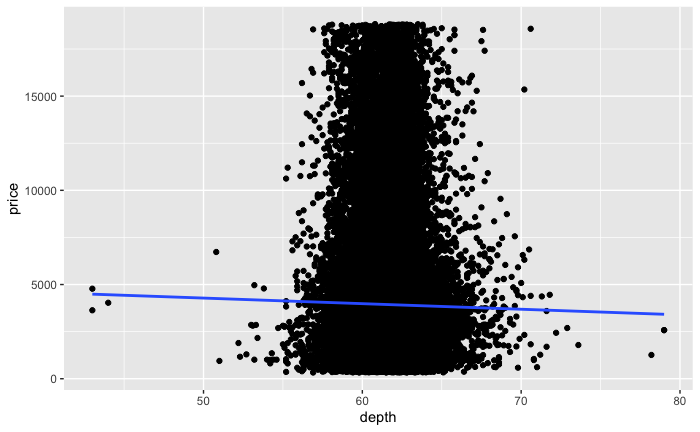

```r
diamonds_clean %>%
  ggplot() +
  aes(x = depth, y = price) +
  geom_point() +
  geom_smooth(method = "lm", se = FALSE)
```

# Investigating the factor levels of the predictors - cut, clarity and color

```r
diamonds_clean %>%
  distinct(cut)
```

| cut |
| --- |
| Ideal |
| Premium |
| Good |
| Very Good |
| Fair |

```r
# its likely 5 dummy variables would be created for cut

diamonds_clean %>%
  distinct(clarity)
```

| clarity |
| --- |
| SI2 |
| SI1 |
| VS1 |
| VS2 |
| VVS2 |
| VVS1 |
| I1 |
| IF |

```r
# its likely 8 dummy variables would be created for clarity

diamonds_clean %>%
  distinct(color)
```

| color |
| --- |
| E |
| I |
| J |
| H |
| F |
| G |
| D |

```r
# its likely 7 dummy variables would be created for color
```

# Using fastDummies and dummy_cols() to generate dummies for the predictors - cut, clarity and color

```r
diamonds_dummy <- diamonds_clean %>%
  dummy_cols(select_columns = c("cut", "clarity", "color"),
             remove_first_dummy = TRUE,
             remove_selected_columns = TRUE)
diamonds_dummy
```

| X1 | carat | depth | table | price | cut_Good | cut_Ideal | cut_Premium | cut_Very Good | clarity_IF | clarity_SI1 | clarity_SI2 | clarity_VS1 | clarity_VS2 | clarity_VVS1 | clarity_VVS2 | color_E | color_F | color_G | color_H | color_I | color_J |
| --- | --- | --- | --- | --- | --- | --- | --- | --- | --- | --- | --- | --- | --- | --- | --- | --- | --- | --- | --- | --- | --- |
| 1 | 0.23 | 61.5 | 55.0 | 326 | 0 | 1 | 0 | 0 | 0 | 0 | 1 | 0 | 0 | 0 | 0 | 1 | 0 | 0 | 0 | 0 | 0 |
| 2 | 0.21 | 59.8 | 61.0 | 326 | 0 | 0 | 1 | 0 | 0 | 1 | 0 | 0 | 0 | 0 | 0 | 1 | 0 | 0 | 0 | 0 | 0 |
| 3 | 0.23 | 56.9 | 65.0 | 327 | 1 | 0 | 0 | 0 | 0 | 0 | 0 | 1 | 0 | 0 | 0 | 1 | 0 | 0 | 0 | 0 | 0 |
| 4 | 0.29 | 62.4 | 58.0 | 334 | 0 | 0 | 1 | 0 | 0 | 0 | 0 | 0 | 1 | 0 | 0 | 0 | 0 | 0 | 0 | 1 | 0 |
| 5 | 0.31 | 63.3 | 58.0 | 335 | 1 | 0 | 0 | 0 | 0 | 0 | 1 | 0 | 0 | 0 | 0 | 0 | 0 | 0 | 0 | 0 | 1 |
| 6 | 0.24 | 62.8 | 57.0 | 336 | 0 | 0 | 0 | 1 | 0 | 0 | 0 | 0 | 0 | 0 | 1 | 0 | 0 | 0 | 0 | 0 | 1 |
| 7 | 0.24 | 62.3 | 57.0 | 336 | 0 | 0 | 0 | 1 | 0 | 0 | 0 | 0 | 0 | 1 | 0 | 0 | 0 | 0 | 0 | 1 | 0 |
| 8 | 0.26 | 61.9 | 55.0 | 337 | 0 | 0 | 0 | 1 | 0 | 1 | 0 | 0 | 0 | 0 | 0 | 0 | 0 | 0 | 1 | 0 | 0 |
| 9 | 0.22 | 65.1 | 61.0 | 337 | 0 | 0 | 0 | 0 | 0 | 0 | 0 | 0 | 1 | 0 | 0 | 1 | 0 | 0 | 0 | 0 | 0 |
| 10 | 0.23 | 59.4 | 61.0 | 338 | 0 | 0 | 0 | 1 | 0 | 0 | 0 | 1 | 0 | 0 | 0 | 0 | 0 | 0 | 1 | 0 | 0 |

[output cut: 990 more lines]